# Testing the Impact of the Affordability Risk Index on the Model

# Context

The ARI is a tool intended to demonstrate the need to preserve affordability in areas that are becoming less affordable at a faster rate. Census tracts where affordability loss risk is greatest receive the highest scores in this index. The ARI uses American Community Survey data to measure change over time across various factors that indicate affordability loss:

- Median Household Income
- Median Home Value
- Families Below the Federal Poverty Level
- Housing Unit Vacancy
- Renter Tenancy
- Individuals Employed in Management, Business, Science and Arts Occupations
- Individuals with a Four-Year Degree (Bachelor’s) or Higher.

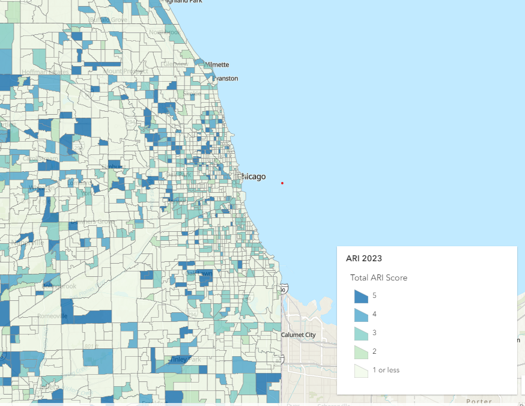

About half the tracts have an ARI of 0. This was pretty poorly demonstrated on their maps, where they had a category of 1 or less. The documentation is as follows:

Scores in the ARI range from one (1) to five (5). See 2023 ARI scores by Census tract. Please note that all Census tracts in Illinois have been reviewed, but some Census tracts that do not meet minimum eligibility standards have received a score of zero (0). Areas identified by the Index as having significant changes across the above factors (either positive or negative change depending on the factor) will receive higher scores.

- 1 point - Family poverty rate meets first threshold (relative rate of change is below the State average relative rate of change)
- 2 points - Family poverty rate meets first point threshold above and housing unit vacancy relative rate of change is below the State average relative rate of change or is below 3.5%
- 3 points - Family poverty rate meets first threshold (relative rate of change is below the State average relative rate of change); housing unit vacancy relative rate of change is below the State average relative rate of change or is below 3.5%; and 2 of the other factor thresholds are met
- 4 points - Family poverty rate is less than the State average and the relative rate of change is below the State average relative rate of change); housing unit vacancy relative rate of change is below the State average relative rate of change or is below 3.5%; and 3 of the other factor thresholds are met
- 5 points - Family poverty rate is less than the State average and the relative rate of change is below the State average relative rate of change); housing unit vacancy relative rate of change is below the State average relative rate of change or is below 3.5%; and 4 of the other factor thresholds are met

## Map of ARI by Census Tract, removing ARI of 0

When removing ARIs of 0, the number of census tracts left in the database diminishes significantly. The number of pin10 observations goes from 1,117,715 to 596,243. My best assumption is that the missing tracts are not experiencing any risk of Affordability (not receiving 1 on any indicator).

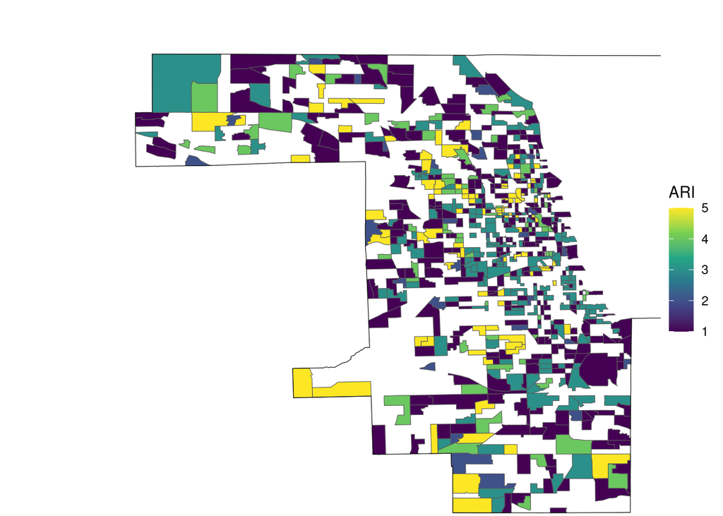

## Map of ARI by Census Tract, Keeping ARI of 0

When keeping the 0s in the map, you can see some clusters of affordability risk, most notably on the North-Western pipeline. With that being said, the map does not seem particularly conclusive regarding regional trends, where there are pockets of high ARIs in the far suburbs. Within the city limits, fives seem to be exclusively in the North, although there are a significant number of fours on the South Side. To be honest, that makes it out to be a pretty interesting metric, which may not align with others in our database.

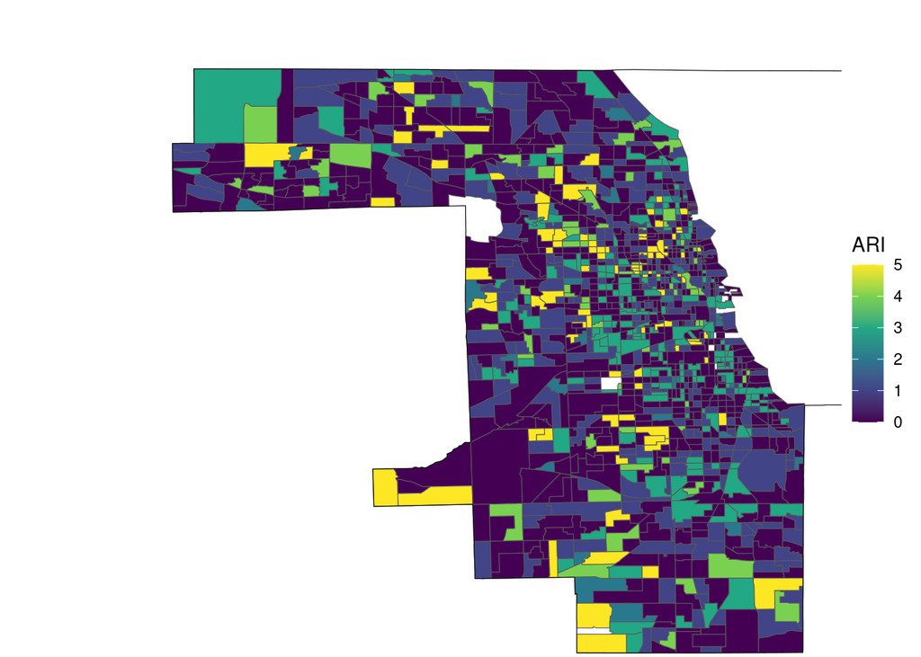

## Does Median SHAP Value Differ by Neighborhood?

In general, it seems as though higher SHAP values relate to higher value neighborhoods. These are concentrated on the North side of the County, often in proximity to Lake Michigan. This is likely due to the model trying to find reasons to increase the value of homes in these areas.

### Median Absolute SHAP Values by Tract

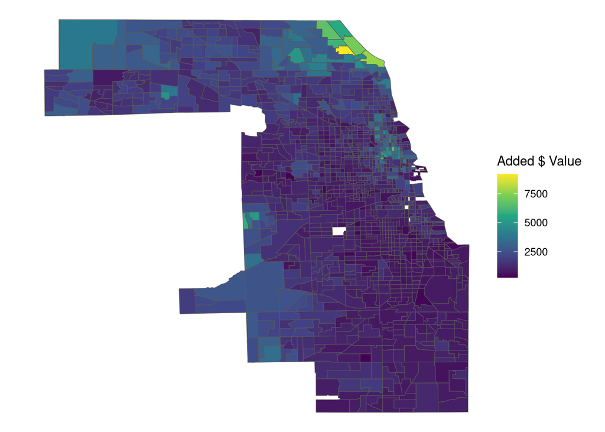

### Median Absolute SHAP Values by Tract, Removing Tracts with 0 ARI

Some of the same patterns are visible when we look at the data without 0 ARI tracts. But, the map is generally more complicated to interpret.

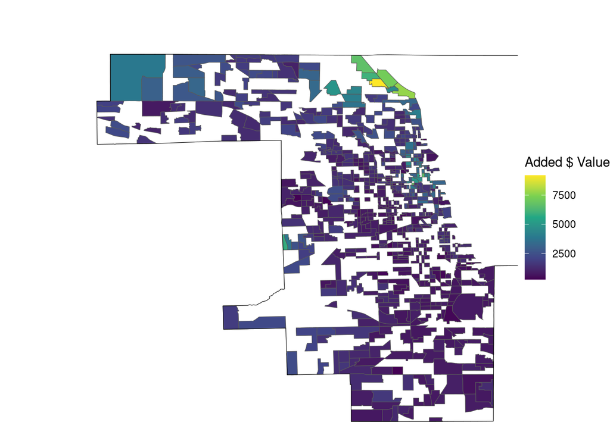

### Median Absolute SHAP Values by Township, Keeping Tracts with 0 ARI

Looking at the data on a less granular level, we can see that the SHAP values are once again higher on the North side of the County. This reflects the findings on the tract level.

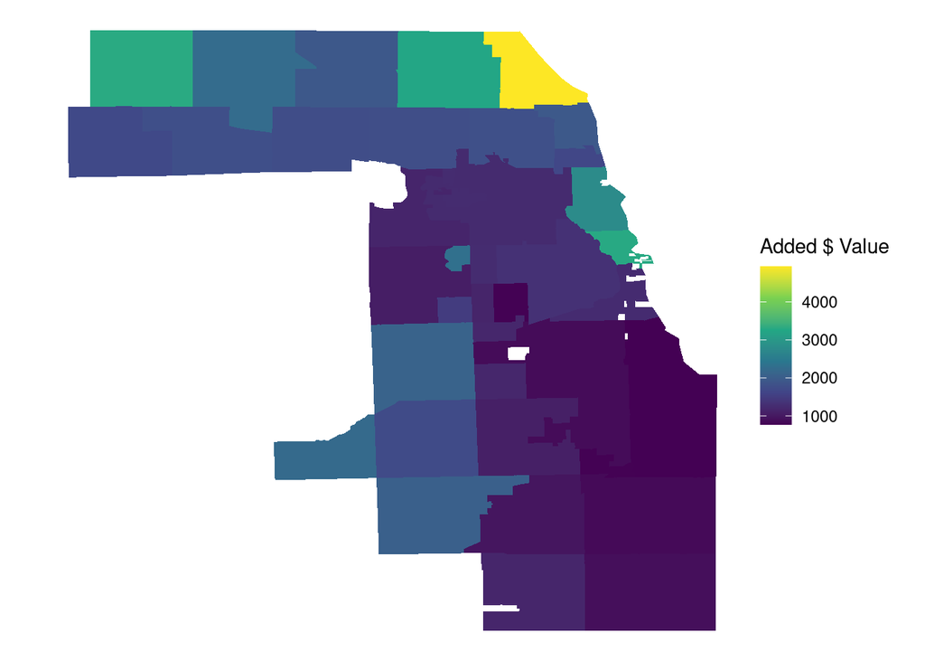

## Median Absolute Values of the 90th percentile in Each Neighborhood

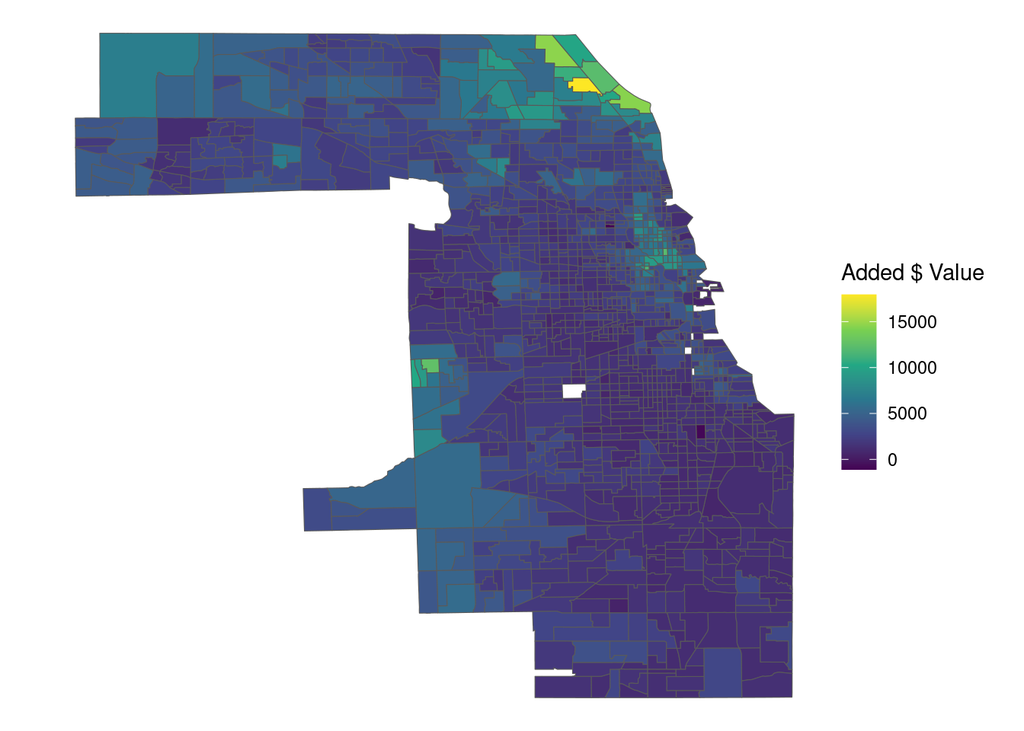

## Correlation between SHAP Value of ARI and ARI

One of the assumptions that can be attached to SHAPs is that if there is a large correlation between the feature value, and the SHAP value, then it is providing something meaningful in the model. In this case, the correlation is around than |.1|. This reinforces the existing perception that it does not add significant value.

```
[1] "Correlation = -0.09"
```

```
[1] "Correlation = -0.12 when removing 0s"
```

## Creating a map to see if there are spatial disparities in the inter-tract SHAP values

A tract with a value of 5 was selected to see if there were any strong spatial disparities with the SHAP values. Within this tract, values ranged from 336 to 3643. As can be seen, values skew significantly higher in the South of the tract, and are lower in the North. A couple explanations for this could be a neighborhood boundary passing through that line, or higher market values in the South.

[interactive chart not shown]

## Does the inclusion of ARI impact metrics on a Township level?

In general, the ARI seemed to have very minimal impact. There were some small shifts in metrics, but a deeper dive also showed nothing significant. It is likely since this is capturing a spatial effect, it is mapping onto the plethora of other spatial effects already in the model.

```
INFO: (Data scanned: 20.71 MB)
```

Intra Model Test Results

| Geography ID | MKI | MKI New | COD | COD New | PRB | PRB New | PRD | PRD New | R Squared | R Squared New |
| --- | --- | --- | --- | --- | --- | --- | --- | --- | --- | --- |
| 70 | 0.75 | 0.75 | 38.36 | 38.33 | -0.24 | -0.24 | 1.16 | 1.17 | 0.82 | 0.82 |
| 71 | 0.78 | 0.78 | 14.42 | 14.45 | -0.11 | -0.12 | 1.03 | 1.03 | 0.81 | 0.81 |
| 72 | 0.68 | 0.69 | 33.58 | 33.61 | -0.39 | -0.38 | 1.16 | 1.15 | 0.66 | 0.66 |
| 73 | 0.90 | 0.90 | 11.84 | 11.96 | -0.04 | -0.04 | 1.02 | 1.02 | 0.91 | 0.91 |
| 74 | 0.96 | 0.97 | 10.03 | 10.28 | -0.01 | 0.00 | 1.01 | 1.01 | 0.95 | 0.95 |
| 75 | 0.79 | 0.79 | 14.20 | 14.01 | -0.08 | -0.08 | 1.03 | 1.03 | 0.80 | 0.80 |
| 76 | 0.83 | 0.82 | 19.01 | 19.22 | -0.13 | -0.14 | 1.06 | 1.07 | 0.91 | 0.91 |
| 77 | 0.93 | 0.93 | 25.50 | 25.57 | -0.12 | -0.12 | 1.09 | 1.09 | 0.90 | 0.91 |

# Conclusion

In general, there was little evidence that the ARI was adding significant value to the model. This was seen in the low correlation between the SHAP values and the ARI, as well as the lack of significant changes in the model metrics. The main takeaway could be made on the fact that there aren’t strong procedures for how new features are treated. Building out a comparison report between a “standard” model and a “new feature” model would be my key recommendation. This could include a comparison of relevant SHAP values (for example does ARI have a positive SHAP value, while the combined “spatial_” SHAP values have a similar collective decrease), as well as a comparison of the model metrics.